# Bellabeat case study

Amr Ghabbour

12/3/2021

## First :

#### Installing package ‘tidyvers’

```r
library(tidyverse)
```

```r
library(ggplot2)
library(dplyr)
library(lubridate)
library(tidyr)
```

## Second :

### you could download same data from [here](https://www.kaggle.com/arashnic/fitbit).

we import the data needed in our analysis for “Bellabeat” case study.

```r
setwd("C:/Users/DELL/Desktop/Fitabase")
activity <- read.csv("dailyActivity_merged.csv")
calories <- read.csv("dailyCalories_merged.csv")
sleep <- read.csv("sleepDay_merged.csv")

colnames(activity)
```

```
##  [1] "Id"                       "ActivityDate"
##  [3] "TotalSteps"               "TotalDistance"
##  [5] "TrackerDistance"          "LoggedActivitiesDistance"
##  [7] "VeryActiveDistance"       "ModeratelyActiveDistance"
##  [9] "LightActiveDistance"      "SedentaryActiveDistance"
## [11] "VeryActiveMinutes"        "FairlyActiveMinutes"
## [13] "LightlyActiveMinutes"     "SedentaryMinutes"
## [15] "Calories"
```

```r
colnames(calories)
```

```
## [1] "Id"          "ActivityDay" "Calories"
```

```r
colnames(sleep)
```

```
## [1] "Id"                 "SleepDay"           "TotalSleepRecords"
## [4] "TotalMinutesAsleep" "TotalTimeInBed"
```

## Third :

#### Data Formating

I did some formating to the dataframe as changing dates to unite them in different dataframes to one formate.

```r
# activity
activity$ActivityDate=as.POSIXct(activity$ActivityDate, format="%m/%d/%Y", tz=Sys.timezone())
activity$date <- format(activity$ActivityDate, format = "%m/%d/%y")
# sleep
sleep$SleepDay=as.POSIXct(sleep$SleepDay, format="%m/%d/%Y %I:%M:%S %p", tz=Sys.timezone())
sleep$date <- format(sleep$SleepDay, format = "%m/%d/%y")
```

## Fourth :

#### Merging dataframes

I merge sleep and activity data frames to make some connections in order to find any patterns.

```r
merged_data <- merge(sleep, activity, by=c("Id","date"))



merged_data_avg <- merged_data %>%
  group_by(date) %>%
  summarise(mean(VeryActiveMinutes),mean(FairlyActiveMinutes),
            mean(LightlyActiveMinutes),mean(Calories),mean(TotalSteps),mean(TotalDistance))
view(merged_data_avg)
```

## Fifth :

#### Analyzing steps

```r
activity %>%
  select(TotalSteps,
         TotalDistance,
         VeryActiveDistance,
         ModeratelyActiveDistance,
         LightActiveDistance) %>%
  summary()
```

```
##    TotalSteps    TotalDistance    VeryActiveDistance ModeratelyActiveDistance
##  Min.   :    0   Min.   : 0.000   Min.   : 0.000     Min.   :0.0000
##  1st Qu.: 3790   1st Qu.: 2.620   1st Qu.: 0.000     1st Qu.:0.0000
##  Median : 7406   Median : 5.245   Median : 0.210     Median :0.2400
##  Mean   : 7638   Mean   : 5.490   Mean   : 1.503     Mean   :0.5675
##  3rd Qu.:10727   3rd Qu.: 7.713   3rd Qu.: 2.053     3rd Qu.:0.8000
##  Max.   :36019   Max.   :28.030   Max.   :21.920     Max.   :6.4800
##  LightActiveDistance
##  Min.   : 0.000
##  1st Qu.: 1.945
##  Median : 3.365
##  Mean   : 3.341
##  3rd Qu.: 4.782
##  Max.   :10.710
```

#### We can see from our data here that most distance spent in the day spent in light activities.

#### As Average of Light activities distance is 3.34 from Average of total distance (5.49).

```r
activity %>%
  select(VeryActiveMinutes,
         FairlyActiveMinutes,
         LightlyActiveMinutes, SedentaryMinutes) %>%
  summary()
```

```
##  VeryActiveMinutes FairlyActiveMinutes LightlyActiveMinutes SedentaryMinutes
##  Min.   :  0.00    Min.   :  0.00      Min.   :  0.0        Min.   :   0.0
##  1st Qu.:  0.00    1st Qu.:  0.00      1st Qu.:127.0        1st Qu.: 729.8
##  Median :  4.00    Median :  6.00      Median :199.0        Median :1057.5
##  Mean   : 21.16    Mean   : 13.56      Mean   :192.8        Mean   : 991.2
##  3rd Qu.: 32.00    3rd Qu.: 19.00      3rd Qu.:264.0        3rd Qu.:1229.5
##  Max.   :210.00    Max.   :143.00      Max.   :518.0        Max.   :1440.0
```

#### We could see the a little time for Hard activities (VeryActivityTimes) in the day of the users of the application compared to light activities time and sedentary time.

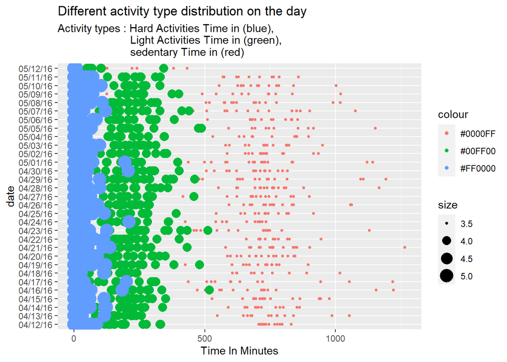

```r
p <- ggplot(data = merged_data) +
  geom_point(aes(y= date , x= SedentaryMinutes, size= 3.5, color="#0000FF"))+
  geom_point(aes(y= date , x= LightlyActiveMinutes, size = 4, color = "#00FF00" ))+
  geom_point(aes(y= date , x= VeryActiveMinutes ,size = 5, color = "#FF0000" ))+
  labs (title = "Different activity type distribution on the day",
        subtitle = "Activity types : Hard Activities Time in (blue),
                        Light Activities Time in (green),
                        sedentary Time in (red)")
p + xlab("Time In Minutes")
```

#### From our below graphs we could conclude that increasing Hard activities time could increase users calories burned per day.

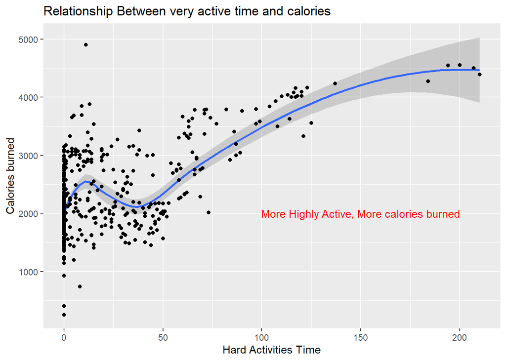

```r
v <- ggplot(data = merged_data, aes(x= VeryActiveMinutes, y= Calories)) +
   geom_smooth()+geom_point() +
   labs(title = "Relationship Between very active time and calories")+
   annotate("text", x=150,y=2000,label="More Highly Active, More calories burned", color = "red")
v + xlab("Hard Activities Time")+ ylab("Calories burned")
```

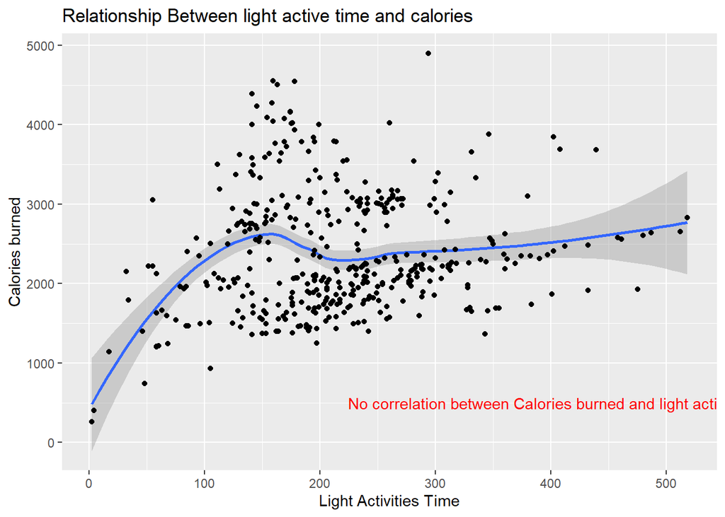

```r
D <- ggplot(data = merged_data, aes(x= LightlyActiveMinutes, y= Calories)) +
   geom_smooth()+geom_point()+
   labs(title = "Relationship Between light active time and calories")+
   annotate("text", x=400,y=500,label="No correlation between Calories burned and light activites ", color = "red")
 D + xlab( "Light Activities Time")+ ylab("Calories burned")
```

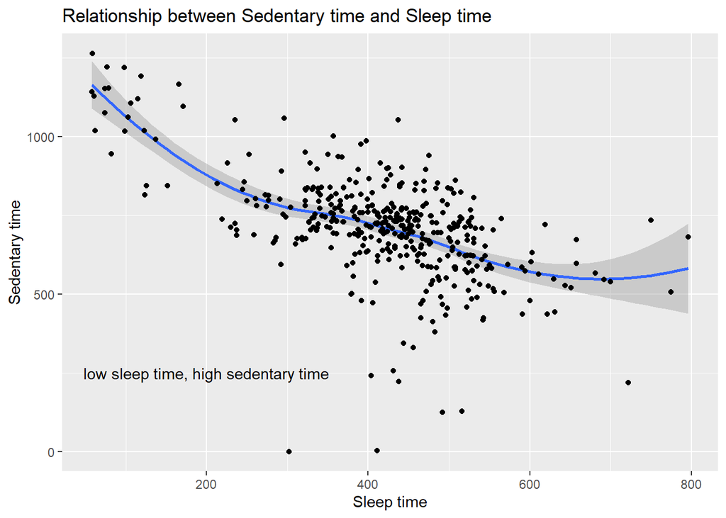

```r
k <- ggplot(data = merged_data , aes(x= TotalMinutesAsleep, y= SedentaryMinutes )) +
   geom_smooth()+geom_point() +
   labs(title="Relationship between Sedentary time and Sleep time")+
   annotate("text", x=200,y=250,label="low sleep time, high sedentary time")
k +xlab("Sleep time")+ ylab("Sedentary time")
```

#### here we could find a negative correlation between sleep time and sedentary time.

#### The more users sleep, th Less sedentary time.

# Weekends vs Workdays

```r
weekends <- slice(merged_data_avg,5,6,13,14,20,21,27,28)
workdays <- slice(merged_data_avg,1,2,3,4,7,8,9,10,11,12,15,16,17,18,19,23,24,25,26,29,30,31)
view(workdays)
view(weekends)
weekends_mean <- weekends %>%  summarise(mean(`mean(LightlyActiveMinutes)`),
                        mean(`mean(FairlyActiveMinutes)`),
                        mean(`mean(VeryActiveMinutes)`),
                        mean(`mean(Calories)`),
                        mean(`mean(TotalSteps)`),
                        mean(`mean(TotalDistance)`))

workdays_mean <- workdays %>%  summarise(mean(`mean(LightlyActiveMinutes)`),
                        mean(`mean(FairlyActiveMinutes)`),
                        mean(`mean(VeryActiveMinutes)`),
                        mean(`mean(Calories)`),
                        mean(`mean(TotalSteps)`),
                        mean(`mean(TotalDistance)`))
head(weekends_mean)
```

```
## # A tibble: 1 x 6
##   `mean(\`mean(Lightl~ `mean(\`mean(Fairly~ `mean(\`mean(Very~ `mean(\`mean(Cal~
##                  <dbl>                <dbl>              <dbl>             <dbl>
## 1                 215.                 17.2               27.3             2372.
## # ... with 2 more variables: mean(`mean(TotalSteps)`) <dbl>,
## #   mean(`mean(TotalDistance)`) <dbl>
```

```r
head(workdays_mean)
```

```
## # A tibble: 1 x 6
##   `mean(\`mean(Lightl~ `mean(\`mean(Fairly~ `mean(\`mean(Very~ `mean(\`mean(Cal~
##                  <dbl>                <dbl>              <dbl>             <dbl>
## 1                 215.                 18.2               23.8             2377.
## # ... with 2 more variables: mean(`mean(TotalSteps)`) <dbl>,
## #   mean(`mean(TotalDistance)`) <dbl>
```

# Sixth :